# Assignment 6

**CS283 Computer Vision, Harvard University, Fall 2019**

**Due Wednesday, Oct. 23, at 5:00pm**

Name: *Natalia M. Pacheco-Tallaj*

This assignment briey reinforces some concepts from image processing and multi-resolution image representations, and it gives you an opportunity to make an informed decision about your finnal project topic. As usual, the assignment will be submitted electronically and formatted according to the guidelines.

```python
# Run this cell (only once) to install the unzip command.
# If you already installed this for previous assignments, no need to reinstall.
! sudo apt install unzip
```

[output not shown]

```python
# Extract required pset folders (make sure you ran the first cell first)
! unzip pset6.zip
```

```
Archive:  pset6.zip
   creating: digs/
```

```python
# Import any required libraries here
import cv2                               # OpenCV
import numpy as np                       # numpy
import scipy.signal                      # Signal package from scipy for convolution

# Use this line to make matplotlib plot inline (only need to call it once when importing matplotlib)
%matplotlib inline

import matplotlib.pyplot as plt
# Modify this line to adjust the displayed plot size. You can also call
# it with different parameters before specific plots.
plt.rcParams['figure.figsize'] = [20, 20]
```

## Question 1 (30 points)

In this problem you will create a hybrid image as described in Oliva et al., ["Hybrid Images"](http://cvcl.mit.edu/hybridimage/hybrid/OlivaTorralb_Hybrid_Siggraph06.pdf) (Proc. SIGGRAPH 2006) and at http://cvcl.mit.edu/hybridimage. Find two grayscale images $I_1$ and $I_2$ that you want to blend. These should be reasonably well aligned, with the two subjects occupying more or less the same part of the image plane. It will be easier if you make them monochromatic (grayscale). Construct a hybrid image from $I_1$ (to be seen from far away) to $I_2$ (to be seen from close-up) as $$I_{\text{hybrid}} = h * I_1 + (I_2 - h * I_2),$$ where $h(x, y)$ is a suitable 2D low-pass filter of your choice.

Experiment with different low-pass filters until you achieve the desired effect of seeing $I_2$ when you are close to your display and $I_1$ when you move back by a meter or two. Describe how the choice of low-pass filter affects your perception of the results, and explain why. Submit your input images, code, results, and discussion in a single `.zip` file as well as an `.html` file, with the images stored in the `./data/` folder of your ZIP archive as described in the submission guidelines.

```python
# im1 is the one that will be seen from afar
def showhybrid(im1, im1low, im1high, im2, im2low, im2high):
    plt.subplot(3,1,1)
    plt.title("Hybrid image")
    plt.imshow(im1low+im2high, cmap='gray')

    plt.subplot(3,3,4)
    plt.title("First image")
    plt.imshow(im1, cmap='gray')
    plt.subplot(3,3,5)
    plt.title("First image, low-passed")
    plt.imshow(im1low, cmap='gray')
    plt.subplot(3,3,6)
    plt.title("First image, high-passed")
    plt.imshow(im1high, cmap='gray')

    plt.subplot(3,3,7)
    plt.title("Second image")
    plt.imshow(im2, cmap='gray')
    plt.subplot(3,3,8)
    plt.title("Second image, low-passed")
    plt.imshow(im2low, cmap='gray')
    plt.subplot(3,3,9)
    plt.title("Second image, high-passed")
    plt.imshow(im2high, cmap='gray')
```

```
(431, 571) (431, 571)
```

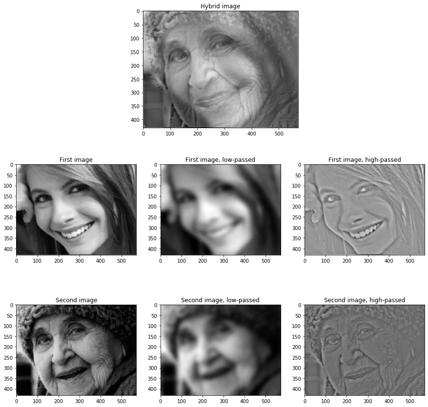

```python
# im1 will be low-passed and thus seen from afar
im1 = cv2.imread('./data/girl', 0) / 255.
im2 = cv2.imread('./data/granny', 0) / 255.

print(im1.shape, im2.shape)

im1high = im1 - cv2.GaussianBlur(im1,(0,0), 9)
im2high = im2 - cv2.GaussianBlur(im2,(0,0), 9)

im1low = cv2.GaussianBlur(im1, (0,0), 9)
im2low = cv2.GaussianBlur(im2, (0,0), 9)

showhybrid(im1, im1low, im1high, im2, im2low, im2high)
```

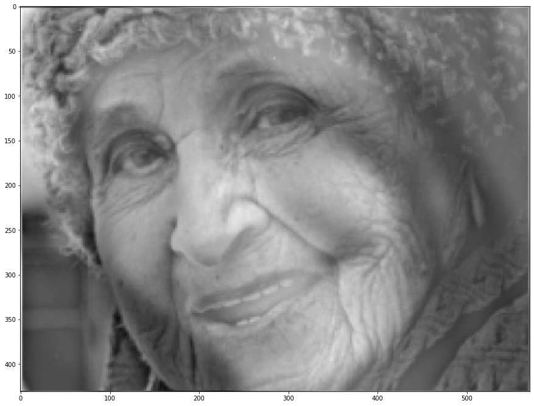

```python
plt.imshow(im1low+im2high, cmap='gray')
```

### Answer:

At first I was trying to simply manually cut off frequencies above and below a certain spot (I took the centered fourier transform of the images and multiplied it by a centered box of 1's with 0's around it or a centered box of 0's with 1's around it for low-pass and high-pass respectively, then took inverse fourier transform and decentered). However, while it was yielding filtered images that looked properly low-passed and high-passed, they didn't look that good when I added them: often one image would predominate completely over the other. Also I think it's probably better to use Gaussians since they have a smooth decay so they probably make for better merged images.

Then I moved to using Gaussians. I can lowpass an image by convolving it with a Gaussian, and high-pass it by subtracting the Gaussian blurred image from the original. At first I tried to manually implement my own Gaussians but for some reason the high-passed images didn't look quite like what they were supposed to. I think this may have been an issue with my constants. Then I switched to using the cv2 library Gaussian blur.

Higher sigmas make the low-passed image blurrier (because convolving with a gaussian with deviation $\sigma$ in the space domain corresponds to multiplying by one with deviation $1/\sigma$ in the fourier domain, and higher $\sigma$ $\implies$ lower $1/\sigma$ $\implies$ we are keeping only the frequencies closer to the origin in the centered fourier transform, i.e. getting rid of more high frequencies and blurring more). Similarly, for the high-passed image, subtracting a blurred image with higher $\sigma$ makes a less high-passed image, because we're subtracting off less frequencies (we kept less frequencies in the higher $\sigma$ blurred image). Subtracting off a lower $\sigma$ blurred image should make it sharper/more high-passed.

In any case, this means that choosing a lower sigma for the high-passed image will made it less noticeable from far away, creating a better transition effect, but also possibly too weak in comparison to the background image to see it well up close. Sometimes if I went too high with the sigma for my low-passed image the shapes in it became too blurred and thus I couldn't really distinguish it when I squinted or moved back a little, and I had to zoom out a lot/move back a lot to see the effect work.

Anyways, I definitely looked very strage walking back and forth in a line in the dining hall to test these out, but they came out pretty cool.

Image sources: I got some of the images from this hybrid images website http://cs.brown.edu/courses/cs129/results/final/kloh/ some from Google, and some from my phone.

# Some other merges

```
(509, 528) (508, 529)
```

[figure not shown]

```python
babynat = cv2.imread('./data/babynat2.png', 0)
monroe = cv2.imread('./data/monroe2.png', 0)

print(babynat.shape, monroe.shape)
monroe = monroe[:, :-1]
babynat = babynat[:-1,:]
assert(babynat.shape == monroe.shape)

im1, im2 = babynat, monroe

im1high = im1 - cv2.GaussianBlur(im1,(0,0), 2.5)
im2high = im2 - cv2.GaussianBlur(im2,(0,0), 2.5)

# original sigma=9 was too blurry, decrease the sigma
im1low = cv2.GaussianBlur(im1, (0,0), 3)
im2low = cv2.GaussianBlur(im2, (0,0), 3)

showhybrid(im1, im1low, im1high, im2, im2low, im2high)
```

[figure not shown]

```python
plt.imshow(im1low+im2high, cmap='gray')
```

```
(373, 468) (375, 468)
```

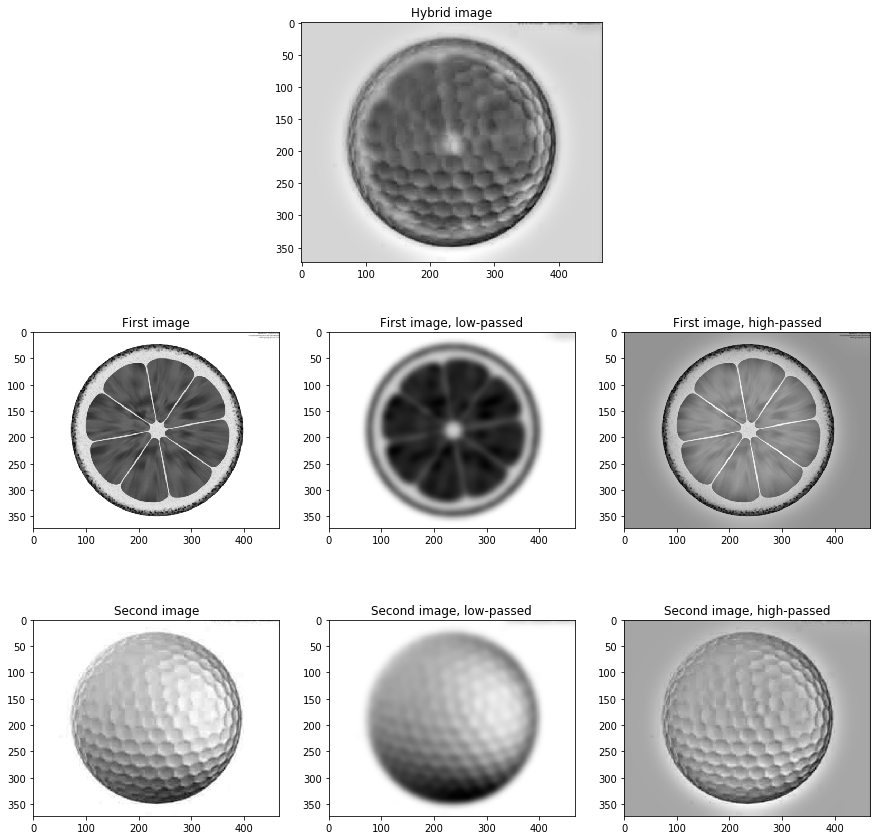

```python
orange  = cv2.imread('./data/orange.png', 0) / 255.
golf = cv2.imread('./data/golf.png', 0) / 255.

print(golf.shape, orange.shape)
orange = orange[:-2]
assert(golf.shape == orange.shape)

im1,im2 = orange, golf

# first attempt, with sigma=9, the high-passed images were too pronounced/shaded
# in (rather than just the lines being more salient), increased sigma to get rid
# of more of the low frequencies
im1high = im1 - cv2.GaussianBlur(im1,(0,0), 20)
im2high = im2 - cv2.GaussianBlur(im2,(0,0), 20)

# low passed images too blurred with sigma=9, probably because these images have
# less detail than the faces? decrease sigma to blur less
im1low = cv2.GaussianBlur(im1, (0,0), 6)
im2low = cv2.GaussianBlur(im2, (0,0), 6)

showhybrid(im1, im1low, im1high, im2, im2low, im2high)
```

```
(665, 1125) (665, 1124)
(665, 1124) (665, 1124)
```

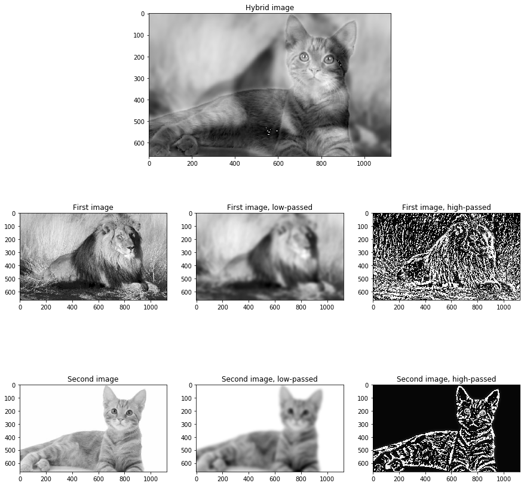

```python
lion2 = cv2.imread('./data/lion2.png', 0)
cat = cv2.imread('./data/kitty.png', 0)

print(lion2.shape, cat.shape)
lion2 = lion2[:,:-1]
print(lion2.shape, cat.shape)

im1, im2 = lion2, cat

im1high = im1 - cv2.GaussianBlur(im1,(0,0), 9)
im2high = im2 - cv2.GaussianBlur(im2,(0,0), 9)

im1low = cv2.GaussianBlur(im1, (0,0), 9)
im2low = cv2.GaussianBlur(im2, (0,0), 9)

showhybrid(im1, im1low, im1high, im2, im2low, im2high)
```

# Old code dump (ignore this)

```python
# low-res is seen from afar. Use low-pass filter on Ifar.
# high-res is seen from near. Use high-pass filter on Inear.

lion  = cv2.imread('./data/lion.png', 0) / 255.
tiger = cv2.imread('./data/tiger.png', 0) / 255.
orange  = cv2.imread('./data/orange.png', 0) / 255.
golf = cv2.imread('./data/golf.png', 0) / 255.

assert(lion.shape == tiger.shape)
h,w = lion.shape

def gauss(sigma, w, h):
    """ Create Gaussian image with standard deviation sigma.
    """

    # Use an odd-size square window with length greater than 5 times sigma
#     w = 2 * np.floor(7 * sigma / 2) + 1
    # CHECK THAT THESE FRACTIONS WORK FOR ANY W,H
    x, y = np.meshgrid(np.arange(-(w-1)/2, (w-1)/2 + 1),
                       np.arange(-(h-1)/2, (h-1)/2 + 1))

#     x, y = np.meshgrid(np.arange(0,w), np.arange(0,h))
    # Equation 4.23 from Szeliski's book. (Actually, he has a small typo; the equation here is correct)
    r2 = x ** 2 + y ** 2  # Compute x^2 + y^2
    return (1 / (2 * np.pi * sigma ** 2)) * np.exp(-r2 / (2 * sigma ** 2))

def gausskernel(sigma):
    """ Create Gaussian kernel with standard deviation sigma.
    """

    # Use an odd-size square window with length greater than 5 times sigma
    w = 2 * np.floor(7 * sigma / 2) + 1
    x, y = np.meshgrid(np.arange(-(w-1)/2, (w-1)/2 + 1),
                       np.arange(-(w-1)/2, (w-1)/2 + 1))

    # Equation 4.23 from Szeliski's book. (Actually, he has a small typo; the equation here is correct)
    r2 = x ** 2 + y ** 2  # Compute x^2 + y^2
    return (1 / (2 * np.pi * sigma ** 2)) * np.exp(-r2 / (2 * sigma ** 2))
```

```python
sigma  = 10
sigmah = 120.

lowpassfilter = np.sqrt(2 * np.pi) * sigma * gauss(sigma, w, h)
highpassfilter = (np.sqrt(2 * np.pi) * sigmah * gauss(sigmah, w, h))


# heres a box of ones and 0s
# highpassfilter = np.ones((h, w))
seg = 3
segdec = 0.48
# highpassfilter[int(h/seg): int((seg -1)*h/seg), int(w/seg):int((seg - 1)*w/seg)] = 0
# highpassfilter[int(h * segdec): int(h - h * segdec), int(w * segdec): int(w - w * segdec)] = 0.1


x,y = np.meshgrid(range(w), range(h))
# centered_img = np.power(-1, x+y) * img
im1fft  = np.fft.fft2(np.power(-1, x+y) * im1)
im2fft = np.fft.fft2(np.power(-1, x+y) * im2)
# im1fft = np.fft.fftshift(np.fft.fft2(im1))
# im2fft = np.fft.fftshift(np.fft.fft2(im2))

plt.rcParams['figure.figsize'] = [15, 15]

# tiger processing
im1low = np.abs(np.fft.ifft2(im1fft * lowpassfilter) * np.power(-1, x+y)) * 255.
im1high = im1 - np.abs(np.fft.ifft2(im1fft * highpassfilter) * np.power(-1, x+y)) * 255.
# im1low = np.abs(np.fft.ifftshift(np.fft.ifft2(im1fft * lowpassfilter)))
# im1high = np.abs(np.fft.ifftshift(np.fft.ifft2(im1fft * highpassfilter)))


# lion processing
im2low = np.abs(np.fft.ifft2(im2fft * lowpassfilter) * np.power(-1, x+y)) * 255.
im2high = im2 - np.abs(np.fft.ifft2(im2fft * highpassfilter) * np.power(-1, x+y)) * 255.
# im2low = np.abs(np.fft.ifftshift(np.fft.ifft2(im2fft * lowpassfilter)))
# im2high = np.abs(np.fft.ifftshift(np.fft.ifft2(im2fft * highpassfilter)))


# normalize
# im1low  = cv2.normalize(im1low, None, alpha=0, beta=255, norm_type=cv2.NORM_MINMAX, dtype=cv2.CV_32F)
# im2high = cv2.normalize(im2high, None, alpha=0, beta=255, norm_type=cv2.NORM_MINMAX, dtype=cv2.CV_32F)

# fig = plt.figure(figsize = (20, 20))
# plt.subplot(2, 3, 1)
# plt.imshow(im1, cmap = 'gray')
# plt.subplot(2, 3, 2)
# plt.imshow(im1low, cmap = 'gray')
# plt.subplot(2, 3, 3)
# plt.imshow(im1high, cmap = 'gray')

# plt.subplot(2, 3, 4)
# plt.imshow(im2, cmap = 'gray')
# plt.subplot(2, 3, 5)
# plt.imshow(im2low, cmap = 'gray')
# plt.subplot(2, 3, 6)
# plt.imshow(im2high, cmap = 'gray')


# plt.imshow(out, vmin = np.min(out), vmax = np.max(out), cmap='gray')
```